# Niger's 2026 rainy season — and El NiñoLa saison des pluies 2026 au Niger — et El Niño

Briefing for the Humanitarian Country Team · 9 September 2026 · OCHA Centre for Humanitarian DataBriefing pour l'Équipe humanitaire pays · 9 septembre 2026 · Centre de données humanitaires de l'OCHA

**Bottom lineL'essentiel**

- A strong El Niño is underway (Niño3.4 ≈ +1.9 °C in August) — but its direct fingerprint on Niger's rains is weak and patchy: on its own, El Niño is not much of a driver here, and not a basis for alarm.Un fort épisode El Niño est en cours (Niño3.4 ≈ +1,9 °C en août) — mais son empreinte directe sur les pluies du Niger est faible et hétérogène : à lui seul, El Niño n'est pas un grand facteur ici, ni un motif d'alarme.
- What is concerning is specific and current: this season's observations for Niger — four independent rainfall datasets and the DMN's own gauges put six departments at a ≥ 1-in-10-year deficit — and the current seasonal forecasts, which account for El Niño together with every other driver, point the same way for the rest of the season.Ce qui préoccupe est spécifique et actuel : les observations de cette saison pour le Niger — quatre jeux de données pluviométriques indépendants et les propres pluviomètres de la DMN placent six départements en déficit ≥ 1 an sur 10 — et les prévisions saisonnières actuelles, qui intègrent El Niño avec tous les autres facteurs, pointent dans le même sens pour la fin de saison.
- By the same yardstick, 2026's rainfall extent equals early-September 2009 — the season behind Niger's largest CERF drought response. And vegetation is now starting to follow in the east: trend-corrected satellite vegetation health has Diffa at its worst late-August in 44 years, putting seven eastern departments in the compound rain-plus-vegetation class — though still well short of 2009's extent at this date.À la même aune, l'étendue pluviométrique de 2026 égale celle de début septembre 2009 — la saison à l'origine de la plus grande réponse sécheresse du CERF au Niger. Et la végétation commence à suivre à l'est : corrigée de la tendance, la santé de la végétation satellitaire place Diffa à sa pire fin août en 44 ans, mettant sept départements de l'est en classe composée pluie + végétation — encore loin, toutefois, de l'étendue de 2009 à cette date.

1 / 9 ocha-dap.github.io/ds-aa-ner-drought/pockets/

## What El Niño does — and doesn't — tell us about NigerCe qu'El Niño dit — et ne dit pas — du Niger

[figure not shown]

- Isolating El Niño's unique signal (1981–2025, other ocean modes held constant): weak and patchy over Niger — a moderate dry tendency in parts of the south-centre and east late in the season, a slight wet tendency in the west mid-season. Nothing that predicts a national drought from the El Niño label alone.En isolant le signal propre d'El Niño (1981–2025, autres modes océaniques tenus constants) : faible et hétérogène sur le Niger — tendance sèche modérée sur une partie du centre-sud et de l'est en fin de saison, légère tendance humide à l'ouest en mi-saison. Rien qui permette de prédire une sécheresse nationale à partir du seul label El Niño.
- The practical consequence: judge the season from seasonal forecasts (which already account for ENSO and every other driver) and, above all, from observations — both follow.Conséquence pratique : juger la saison sur les prévisions saisonnières (qui intègrent déjà l'ENSO et tous les autres facteurs) et, surtout, sur les observations — les deux suivent.

2 / 9ERA5 × Niño3.4 (NOAA PSL), partial correlation · OCHA CHD teleconnections

## The rest of the season, per the forecastsLa fin de saison, selon les prévisions

[figure not shown]

- With July–August observed, the season-closing JAS estimate is the driest of the 46-year record (per the ERA5-based system, which runs anomalously dry this year — the direction is corroborated by the observation datasets on the next slides, the extremity less so).Juillet–août observés, l'estimation de clôture JAS est la plus sèche de l'historique de 46 ans (selon le système fondé sur ERA5, anormalement sec cette année — la direction est corroborée par les jeux de données d'observation des diapositives suivantes, l'extrémité moins).
- The remaining true forecast — September–November, the harvest and pasture-regrowth window — tilts dry: ~1-in-4 nationally, up to 1-in-10 in Dosso/Tillabéri pockets.La véritable prévision restante — septembre–novembre, fenêtre des récoltes et de la repousse des pâturages — penche au sec : ~1 an sur 4 au niveau national, jusqu'à 1 an sur 10 dans des poches de Dosso/Tillabéri.

3 / 9ECMWF SEAS5, issuedémission 09/2026 · OCHA CHD skill methodology

## ASAP warningsAlertes ASAP

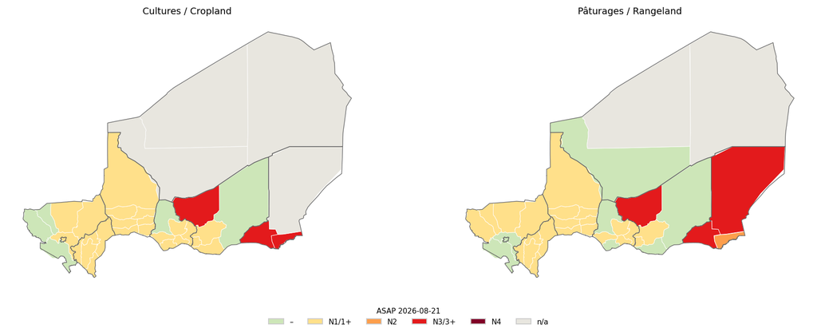

- The EC/JRC ASAP system issues automated agricultural-drought warnings per unit and land cover every 10 days. Current picture: warnings on 29 of 35 units (cropland and/or rangeland) — the Dosso–Tahoua–Tillabéri belt at level 1/1+, and level-3 warnings — poor growth with negative prospects, from water balance AND biomass — on Diffa, Maïné-Soroa and Tanout croplands, level 3+ on N'Guigmi rangelands.Le système ASAP de la CE/JRC émet tous les 10 jours des alertes automatiques de sécheresse agricole par unité et type de couvert. Tableau actuel : alertes sur 29 des 35 unités (cultures et/ou pâturages) — la bande Dosso–Tahoua–Tillabéri en niveau 1/1+, et des alertes de niveau 3 — croissance médiocre et perspectives négatives, sur bilan hydrique ET biomasse — sur les cultures de Diffa, Maïné-Soroa et Tanout, niveau 3+ sur les pâturages de N'Guigmi.
- The region-scale vegetation indices agree once their long-term trend is removed: on the detrended VHI, Diffa is at its worst late-August of the 44-year record and Zinder and Tahoua are near the 1-in-5 level — the same eastern geography as ASAP's level-3 warnings. Impacts lag rainfall; the September dekads are the watchpoint.Les indices de végétation à l'échelle régionale concordent une fois leur tendance de long terme retirée : sur le VHI détendancé, Diffa est à sa pire fin août des 44 ans d'historique et Zinder et Tahoua près du niveau 1 an sur 5 — la même géographie orientale que les alertes de niveau 3 d'ASAP. Les impacts suivent la pluie ; les décades de septembre sont le point de vigilance.

4 / 9EC/JRC ASAP, agricultural-production-hotspots.ec.europa.eu · dekaddécade 21–31/08/2026

## What has already been observedCe qui est déjà observé

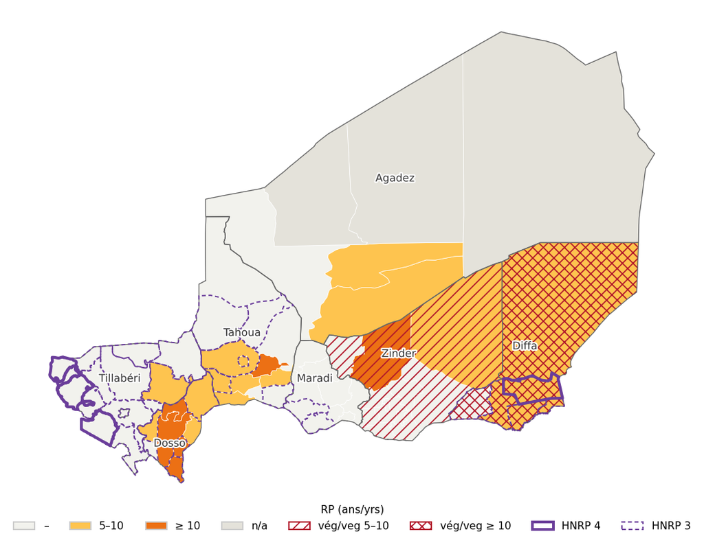

- Four independent rainfall datasets (CHIRPS, IMERG, the DMN's ENACTS, SEAS5+ERA5) are combined per department; classes require majority agreement.Quatre jeux de données pluviométriques indépendants (CHIRPS, IMERG, l'ENACTS de la DMN, SEAS5+ERA5) sont combinés par département ; les classes exigent un accord majoritaire.
- Severe rainfall deficit (≥ 1-in-10-year, orange): Keita (Tahoua), Dioundiou, Dosso, Gaya, Loga (Dosso), Tanout (Zinder). 18 more departments on watch, including eastern Diffa and the Tahoua belt.Déficit pluviométrique sévère (≥ 1 an sur 10, orange) : Keita (Tahoua), Dioundiou, Dosso, Gaya, Loga (Dosso), Tanout (Zinder). 18 autres départements en vigilance, dont l'est de Diffa et la bande de Tahoua.
- The national met service's own gauges concur in the east: four stations coded August in their driest quintile against DMN's 30-year normals; five recorded their 2nd-driest June–August on record.Les pluviomètres du service météorologique national concordent à l'est : quatre stations codent août dans leur quintile le plus sec par rapport aux normales trentenaires de la DMN ; cinq enregistrent leur 2ᵉ juin–août le plus sec.
- Thick purple outline: the four HNRP severity-4 departments (thin dashed: severity 3). On the combined (majority) indicator only N'Guigmi reaches watch — but each of the four is in deficit in at least one dataset: IMERG has N'Guigmi at its driest June–August on record, and Téra, Bankilaré and Torodi at 1-in-7 to 1-in-15, while the gauge-anchored datasets read them closer to normal.Contour violet épais : les quatre départements en sévérité 4 du HNRP (tirets fins : sévérité 3). Sur l'indicateur combiné (majoritaire), seul N'Guigmi atteint la vigilance — mais chacun des quatre est en déficit dans au moins un jeu de données : IMERG place N'Guigmi à son juin–août le plus sec de l'historique, et Téra, Bankilaré et Torodi entre 1 an sur 7 et 1 an sur 15, tandis que les jeux ancrés sur les pluviomètres les lisent plus proches de la normale.

5 / 9CHIRPS · IMERG · ENACTS · SEAS5+ERA5 · FAO ASIS · OGIMET/DMN · HNRP 2026

## Every season since 2000, at this same point of the yearChaque saison depuis 2000, au même moment de l'année

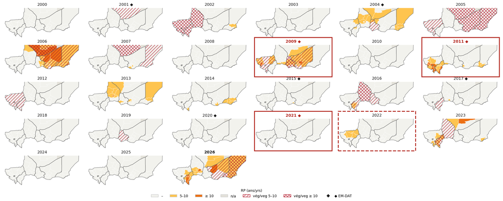

- Each panel: the combined indicator as it stood in early September of that season, zoomed to the agricultural belt (fills: rainfall; red hatching: vegetation). Red frames: seasons that later drew a CERF drought response; dashed: the 2022 AA activation; ◆: a drought event in EM-DAT's disaster registry.Chaque panneau : l'indicateur combiné tel qu'il se présentait début septembre de la saison, zoomé sur la bande agricole (aplats : pluie ; hachures rouges : végétation). Cadres rouges : saisons ayant ensuite donné lieu à une réponse sécheresse du CERF ; tirets : l'activation AA de 2022 ; ◆ : événement de sécheresse du registre EM-DAT.
- Read honestly, the record shows both skill and limits: 2009, 2011 and (partially) 2004 stand out at this date, but 2001, 2015, 2017, 2020 and 2021 were quiet in early September — late-collapse or patchy droughts this June–August lens misses — while 2006 and 2023 were loud with no drought event following. Early September is a checkpoint, not a verdict; hence the end-of-September re-run.Lu honnêtement, l'historique montre à la fois la capacité et les limites : 2009, 2011 et (partiellement) 2004 ressortent à cette date, mais 2001, 2015, 2017, 2020 et 2021 étaient calmes début septembre — sécheresses tardives ou localisées que cette lecture juin–août manque — tandis que 2006 et 2023 étaient chargés sans événement de sécheresse à la clé. Début septembre est un point de contrôle, pas un verdict ; d'où la réexécution fin septembre.

6 / 9 same pipeline, 2000–2026 · EM-DAT (CRED)même chaîne de traitement, 2000–2026 · EM-DAT (CRED)

## How 2026 compares — and what it means2026 en comparaison — et ce que cela implique

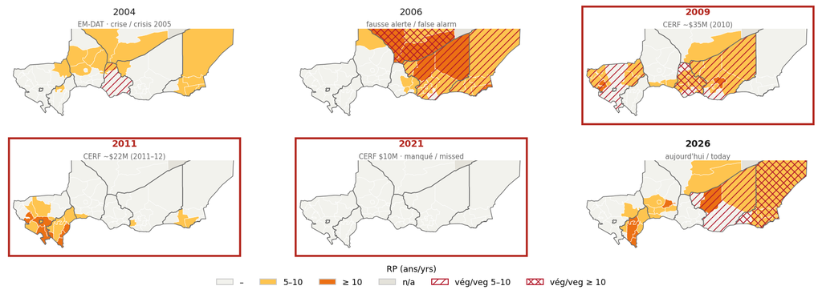

- The indicator flagged the CERF drought seasons at this same point of the year — 2009 (24 units, ≈US$35M of CERF responses) and 2011 (20 units, ≈$22M) — and, with August observed, it partially catches 2004, the eastern season behind the 2005 food crisis (3.0M people affected per EM-DAT). 2026 matches 2009's extent.L'indicateur signalait les saisons de sécheresse CERF au même moment de l'année — 2009 (24 unités, ≈35 M$ de réponses CERF) et 2011 (20 unités, ≈22 M$) — et, août observé, il capte partiellement 2004, la saison orientale à l'origine de la crise alimentaire de 2005 (3,0 M de personnes affectées selon EM-DAT). 2026 égale l'étendue de 2009.
- It can also over-call: 2006 was loud (23 units in rainfall deficit, with vegetation stress alongside) yet no bad year followed — even a compound signal can false-alarm, which is why harvest and food-security confirmation (Cadre Harmonisé) matter. And 2021 shows the blind spot — its rains collapsed in September itself. A quiet early-September map is not an all-clear; a loud one, as now, is meaningful but not yet a verdict.Il peut aussi trop alerter : 2006 était chargé (23 unités en déficit pluviométrique, avec du stress de la végétation en plus) sans mauvaise année à la clé — même un signal composé peut produire une fausse alerte, d'où l'importance de la confirmation par les récoltes et la sécurité alimentaire (Cadre harmonisé). Et 2021 montre l'angle mort — ses pluies se sont effondrées en septembre même. Une carte calme début septembre n'est pas un feu vert ; une carte chargée, comme aujourd'hui, est significative mais pas encore un verdict.

7 / 9 framework bad-year record · aa.cerf_allocationregistre des mauvaises années du cadre · aa.cerf_allocation

## 35 seasons in one chart — and what to do now35 saisons en un graphique — et la suite

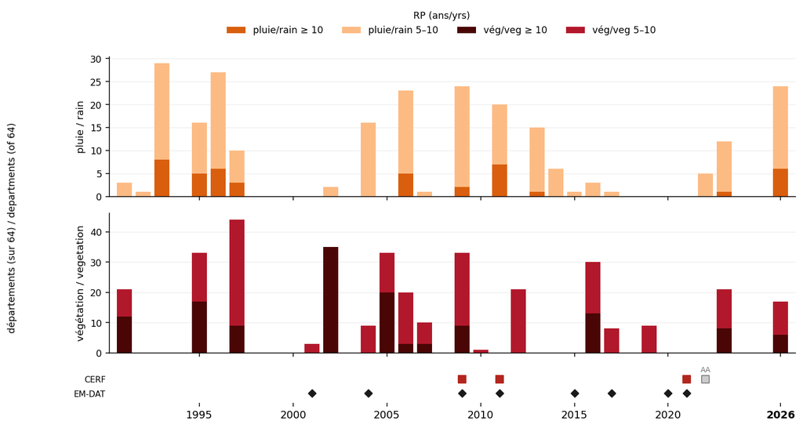

- Top: departments in rainfall deficit (RP ≥ 5; dark: ≥ 10). Bottom: departments whose region shows vegetation stress (trend-corrected; dark: ≥ 10). The strip below flags CERF drought seasons (red squares) and drought events in EM-DAT's disaster registry since 2000 (black diamonds). 2026's rainfall count is the largest since 2009–2011; its vegetation count is still well below 2009's, but it coincides with the rainfall deficit in a single eastern belt — how far it spreads in September is the key uncertainty.Haut : départements en déficit pluviométrique (PR ≥ 5 ; foncé : ≥ 10). Bas : départements dont la région montre un stress de la végétation (corrigé de la tendance ; foncé : ≥ 10). Le bandeau signale les saisons de sécheresse CERF (carrés rouges) et les événements de sécheresse du registre EM-DAT depuis 2000 (losanges noirs). Le décompte pluviométrique de 2026 est le plus élevé depuis 2009–2011 ; celui de la végétation reste bien sous celui de 2009, mais il coïncide avec le déficit de pluie dans une même bande orientale — son extension en septembre est la grande incertitude.
- What we will monitor: the hotspot departments (live page below); the September rainfall and vegetation dekads and the ASAP end-of-season classification; then a re-run of this same analysis at the end of September, read against the three scenarios on the next slide — with particular attention to where deficits overlap HNRP severity-4 areas (eastern Diffa, western Tillabéri).Ce que nous suivrons : les départements sensibles (page en direct ci-dessous) ; les pluies et décades de végétation de septembre et la classification ASAP de fin de saison ; puis une réexécution de cette même analyse fin septembre, lue à l'aune des trois scénarios de la diapositive suivante — avec une attention particulière aux recoupements entre déficits et zones en sévérité 4 du HNRP (est de Diffa, ouest de Tillabéri).

8 / 9 ocha-dap.github.io/ds-aa-ner-drought/pockets/

## Three scenarios to reassess at the end of SeptemberTrois scénarios à réévaluer fin septembre

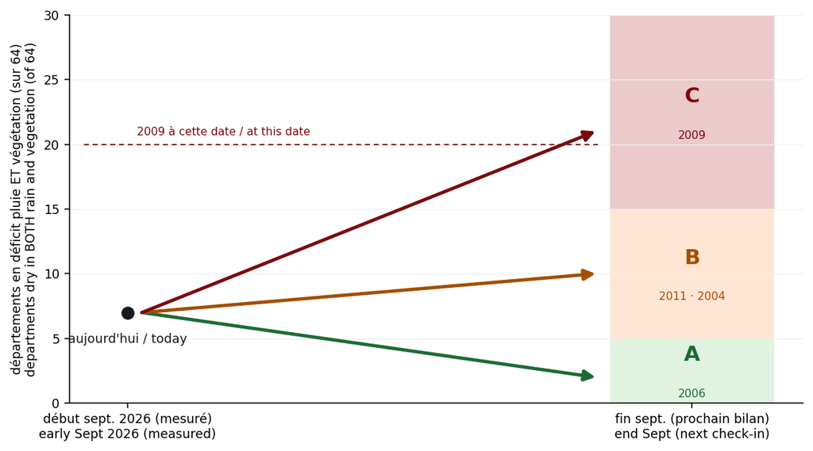

|  | A — Late-season recovery | B — Confirmed drought, localized east | C — Widespread 2009-type failure |
| --- | --- | --- | --- |
| By end Sept we'd see | September rains recover; vegetation stress recedes — fewer than 5 departments dry in both rain and vegetation; no new ASAP level 3 | Deficits persist; the rain-and-vegetation overlap stays eastern (5–15 departments); ASAP level 3 confined to the east | Vegetation spreads west (overlap ≥ 15 departments); ASAP level 3/4 beyond the east |
| Analogues | 2006 — no EM-DAT drought event, no CERF drought response | 2011 — CERF ≈US$22M · 3.0M affected (EM-DAT) 2004 — 3.0M affected (EM-DAT) | 2009 — CERF ≈US$35M · 7.9M affected (EM-DAT) |
| What followed in those years | Nothing unusual — a normal harvest and lean season; 2006 is logged as a false alarm of the rainfall signal | 2011 → the hard 2012 lean season, concentrated in the west; 2004 → the 2005 food crisis (drought plus locusts), concentrated in the east | 2009 → the 2010 nationwide food crisis |

|  | A — Redressement de fin de saison | B — Sécheresse confirmée, localisée à l'est | C — Défaillance généralisée type 2009 |
| --- | --- | --- | --- |
| Ce qu'on verrait fin sept. | Les pluies de septembre se redressent ; le stress de la végétation recule — moins de 5 départements secs à la fois en pluie et en végétation ; pas de nouveau niveau 3 ASAP | Les déficits persistent ; le recoupement pluie-végétation reste à l'est (5–15 départements) ; niveau 3 ASAP confiné à l'est | La végétation s'étend vers l'ouest (recoupement ≥ 15 départements) ; niveau 3/4 ASAP au-delà de l'est |
| Analogues | 2006 — aucun événement sécheresse EM-DAT, aucune réponse sécheresse du CERF | 2011 — CERF ≈22 M$ · 3,0 M affectés (EM-DAT) 2004 — 3,0 M affectés (EM-DAT) | 2009 — CERF ≈35 M$ · 7,9 M affectés (EM-DAT) |
| Ce qui a suivi ces années-là | Rien d'inhabituel — récolte et soudure normales ; 2006 est consigné comme fausse alerte du signal pluviométrique | 2011 → la soudure difficile de 2012, concentrée à l'ouest ; 2004 → la crise alimentaire de 2005 (sécheresse plus criquets), concentrée à l'est | 2009 → la crise alimentaire nationale de 2010 |

The chart counts departments where BOTH the rainfall and the vegetation indicators signal drought (RP ≥ 5 each) — today 7, all in the east; the end-September check-in re-runs this analysis on the last September dekad. Analogue years are placed by what they measured at this same check-in, not by their outcomes. B is the central case, given the advanced season and the dry September–November forecast tilt.Le graphique compte les départements où la pluie ET la végétation signalent la sécheresse (PR ≥ 5 chacune) — aujourd'hui 7, tous à l'est ; le bilan de fin septembre réexécute cette analyse sur la dernière décade de septembre. Les années analogues sont placées selon ce qu'elles mesuraient à ce même bilan, pas selon leurs issues. B est le scénario central, vu l'avancement de la saison et la tendance sèche de la prévision septembre–novembre.

The 2021 caveat: 2021 measured near zero here — its rains failed in September itself — yet it ended in the record 2022 lean season (CERF US$10M · 4.4M affected, EM-DAT). Hence September rainfall and the vegetation dekads are monitored in their own right.La réserve 2021 : 2021 mesurait ici près de zéro — ses pluies ont échoué en septembre même — et s'est pourtant soldée par la soudure record de 2022 (CERF 10 M$ · 4,4 M affectés, EM-DAT). D'où le suivi des pluies de septembre et des décades de végétation à part entière.

9 / 9 ocha-dap.github.io/ds-aa-ner-drought/pockets/

## Backup — food security after past seasons (Cadre Harmonisé)Annexe — la sécurité alimentaire après les saisons passées (Cadre harmonisé)

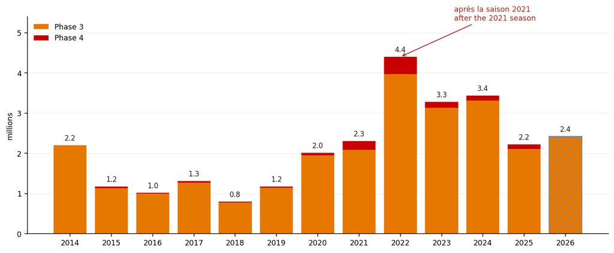

- June–August lean-season population in CH phase 3+ (projected each spring). After the 2021 drought season, the 2022 lean season reached 4.4 million in phase 3+ — including 426,000 in phase 4, both records of the CH era and roughly double the pre-drought year.Population en phase 3+ du CH pendant la soudure juin–août (projetée chaque printemps). Après la saison de sécheresse 2021, la soudure 2022 a atteint 4,4 millions en phase 3+ — dont 426 000 en phase 4, deux records de l'ère CH et environ le double de l'année précédente.
- Read with care: CH outcomes reflect conflict, prices, access and assistance as much as rainfall — they map imperfectly onto drought indicators (2022 followed the 2021 drought, but 2023–24 stayed high amid the regional political and economic crisis). The 2026 bar (hatched) was projected before this season; the November 2026 CH analysis is the first number that will price in this season's outcome.À lire avec prudence : les résultats du CH reflètent le conflit, les prix, l'accès et l'assistance autant que la pluie — ils se superposent imparfaitement aux indicateurs de sécheresse (2022 suit la sécheresse 2021, mais 2023–24 restent élevés dans le contexte de la crise politique et économique régionale). La barre 2026 (hachurée) a été projetée avant cette saison ; l'analyse CH de novembre 2026 sera le premier chiffre à intégrer l'issue de cette saison.

backupannexe Cadre harmonisé (CILSS/HDX)